# Validating some Beliefs about Income Bias

### Hypothesis 9: There is a bias in income based on the country of origin

Finally, let’s see how earning power is related to a person’s country of origin:

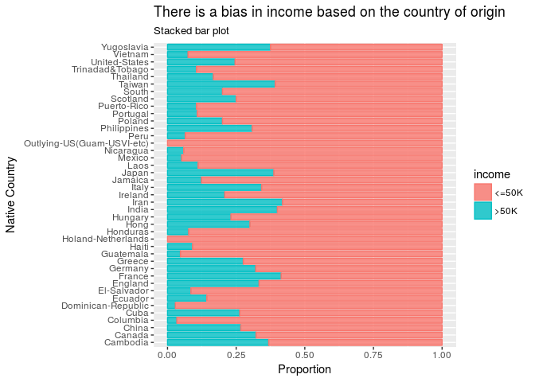

```r
ggplot(dataset, aes(x = native.country, fill = income, color = income)) +
   geom_bar(alpha = 0.8, width = 0.8, position = "fill") +
   coord_flip() +
   labs(x = "Native Country", y = "Proportion", title = "There is a bias in income based on the country of origin",
        subtitle = "Stacked bar plot")
```

```r
prop.table(table(dataset$native.country, dataset$income), 1) * 100
```

```
##
##                                   <=50K       >50K
##   Cambodia                    63.157895  36.842105
##   Canada                      67.768595  32.231405
##   China                       73.333333  26.666667
##   Columbia                    96.610169   3.389831
##   Cuba                        73.684211  26.315789
##   Dominican-Republic          97.142857   2.857143
##   Ecuador                     85.714286  14.285714
##   El-Salvador                 91.509434   8.490566
##   England                     66.666667  33.333333
##   France                      58.620690  41.379310
##   Germany                     67.883212  32.116788
##   Greece                      72.413793  27.586207
##   Guatemala                   95.312500   4.687500
##   Haiti                       90.909091   9.090909
##   Holand-Netherlands         100.000000   0.000000
##   Honduras                    92.307692   7.692308
##   Hong                        70.000000  30.000000
##   Hungary                     76.923077  23.076923
##   India                       60.000000  40.000000
##   Iran                        58.139535  41.860465
##   Ireland                     79.166667  20.833333
##   Italy                       65.753425  34.246575
##   Jamaica                     87.654321  12.345679
##   Japan                       61.290323  38.709677
##   Laos                        88.888889  11.111111
##   Mexico                      94.867807   5.132193
##   Nicaragua                   94.117647   5.882353
##   Outlying-US(Guam-USVI-etc) 100.000000   0.000000
##   Peru                        93.548387   6.451613
##   Philippines                 69.191919  30.808081
##   Poland                      80.000000  20.000000
##   Portugal                    89.189189  10.810811
##   Puerto-Rico                 89.473684  10.526316
##   Scotland                    75.000000  25.000000
##   South                       80.000000  20.000000
##   Taiwan                      60.784314  39.215686
##   Thailand                    83.333333  16.666667
##   Trinadad&Tobago             89.473684  10.526316
##   United-States               75.407522  24.592478
##   Vietnam                     92.537313   7.462687
##   Yugoslavia                  62.500000  37.500000
```

We can see that Taiwanese, French, Iranians, and Indians are the most well-earning people among different countries.

## Classification using Machine Learning Models

How can we combine all these variables to predict the income level of an unseen person?

The answer is: Machine Learning!

### Decision Tree

- Decision trees can deal with categorical variables directly.
- They don’t require data scaling.

```r
# Split data: 70% for training
set.seed(1024)
tr.idx <- caret::createDataPartition(dataset$income, p = 0.7, list = FALSE)

# Fit a decision tree
tree.model <- caret::train(form = income ~ ., data = dataset[tr.idx,],
                           method = "rpart")

# Predict test set
tree.pred <- predict(tree.model, newdata = dataset[-tr.idx,])

# Performance
classAccuracy <- function(y, yhat) {
   sum(yhat == y) / length(y)
}
classAccuracy(dataset$income[-tr.idx], tree.pred)
```

```
## [1] 0.8162367
```

### K Nearest Neighbor (KNN)

- Non-linear learner.
- Simple to understand and implement.

```r
# Encode categorical features
x <- model.matrix(income ~ . -1, data = dataset)
y <- dataset$income
dim(x)
```

```
## [1] 32561    95
```

```r
# Fit KNN using the 'dist' method
knn.model <- fastknn(x[tr.idx,], y[tr.idx], x[-tr.idx,], k = 25)
classAccuracy(dataset$income[-tr.idx], knn.model$class)
```

```
## [1] 0.8001638
```

```r
# Fit KNN using the 'vote' method
knn.model <- fastknn(x[tr.idx,], y[tr.idx], x[-tr.idx,], k = 25,
                     method = "vote")
classAccuracy(dataset$income[-tr.idx], knn.model$class)
```

```
## [1] 0.8029279
```

```r
# Fit KNN using the 'dist' method with normalization
knn.model <- fastknn(x[tr.idx,], y[tr.idx], x[-tr.idx,], k = 25,
                     method = "vote", normalize = "robust")
classAccuracy(dataset$income[-tr.idx], knn.model$class)
```

```
## [1] 0.8231982
```

```r
# Find the best k
set.seed(2048)
cv.out <- fastknnCV(x[tr.idx,], y[tr.idx], k = seq(from = 10, to = 30, by = 5),
                    method = "vote", normalize = "robust",
                    folds = 10, nthread = 8)
cv.out$cv_table
```

| fold_1 | fold_2 | fold_3 | fold_4 | fold_5 | fold_6 | fold_7 | fold_8 | fold_9 | fold_10 | mean | k |
| --- | --- | --- | --- | --- | --- | --- | --- | --- | --- | --- | --- |
| 0.175 | 0.172 | 0.185 | 0.171 | 0.164 | 0.162 | 0.174 | 0.172 | 0.165 | 0.170 | 0.171 | 10 |
| 0.178 | 0.173 | 0.181 | 0.171 | 0.160 | 0.163 | 0.171 | 0.169 | 0.159 | 0.161 | 0.169 | 15 |
| 0.177 | 0.167 | 0.177 | 0.164 | 0.164 | 0.164 | 0.168 | 0.168 | 0.159 | 0.167 | 0.168 | 20 |
| 0.176 | 0.168 | 0.183 | 0.163 | 0.165 | 0.160 | 0.168 | 0.172 | 0.161 | 0.162 | 0.168 | 25 |
| 0.174 | 0.169 | 0.179 | 0.165 | 0.168 | 0.162 | 0.163 | 0.172 | 0.155 | 0.163 | 0.167 | 30 |

### Random Forest

- Combine simple models (decision trees) to build a more complex one.
- The base models can be trained in parallel.
- Allow to rank features.

```r
# Fit Random Forest
rf.model <- ranger::ranger(income ~ ., dataset[tr.idx,], num.trees = 500,
                           mtry = 2, importance = "impurity", num.threads = 8)

# Predict test set
rf.pred <- predict(rf.model, dataset[-tr.idx,])

# Performance
classAccuracy(dataset$income[-tr.idx], rf.pred$predictions)
```

```
## [1] 0.8390663
```

```r
# Variable importance
var.imp <- ranger::importance(rf.model)
var.imp <- dplyr::data_frame(variable = names(var.imp), importance = var.imp) %>%
   dplyr::arrange(desc(importance))
var.imp
```

| variable | importance |
| --- | --- |
| relationship | 843.884 |
| education.num | 778.964 |
| age | 715.014 |
| marital.status | 641.721 |
| hours.per.week | 476.212 |
| occupation | 334.787 |
| education | 286.071 |
| workclass | 189.650 |
| sex | 140.885 |
| native.country | 93.733 |
| race | 80.242 |